# Exponential Smoothing Methods

Piotr Wieczorek

2023-06-27

```r
library(tidyverse)
library(forecast)
library(tseries)
library(expsmooth)
library(ggpubr)
library(png)
library(scales)
```

## **Simple Exponential Smoothing (SES)**

### This method is practical when there is no trend and no seasonality in the time series data. It essentialy gives weight (alpha) to past observations, where the “newest” observations get higher weights than the “oldest” data points in contradiction to the mean method, where all observatinos get the same weight. In SES the weights decrease exponentially.

### Formula:

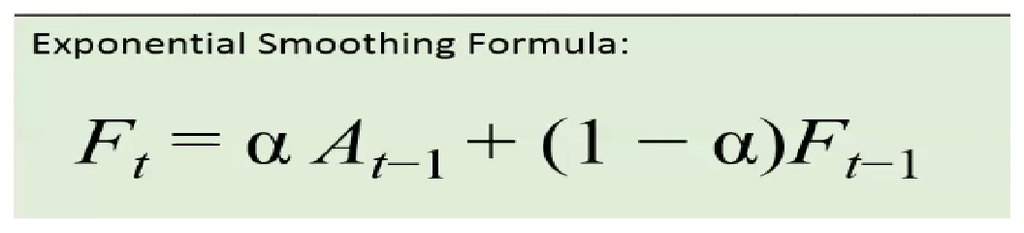

```r
ggplot() +
    background_image(readPNG("images/ses_formula3.png"))
```

### The same formula can be written as:

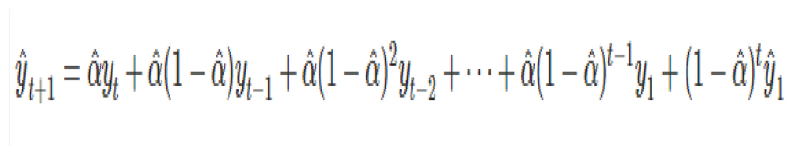

```r
ggplot() +
    background_image(readPNG("images/ses_formula4.png"))
```

### We will use ‘ausair’ time series from the fpp2 package for the SES model

```r
ses_ts <- fpp2::ausair
```

```r
time(ses_ts)
```

```
## Time Series:
## Start = 1970
## End = 2016
## Frequency = 1
##  [1] 1970 1971 1972 1973 1974 1975 1976 1977 1978 1979 1980 1981 1982 1983 1984
## [16] 1985 1986 1987 1988 1989 1990 1991 1992 1993 1994 1995 1996 1997 1998 1999
## [31] 2000 2001 2002 2003 2004 2005 2006 2007 2008 2009 2010 2011 2012 2013 2014
## [46] 2015 2016
```

```r
ses_ts <- window(ses_ts,start = 1989, end = 2016, frequency = 1)
ses_ts <- diff(ses_ts)
```

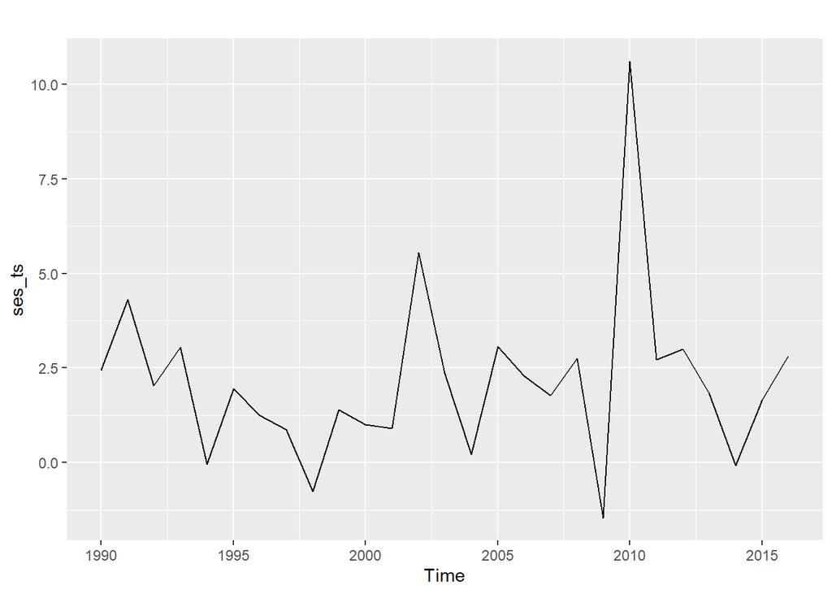

```r
autoplot(ses_ts)
```

```r
ses(ses_ts,h=5)
```

```
##      Point Forecast      Lo 80    Hi 80     Lo 95    Hi 95
## 2017       2.129154 -0.8261965 5.084505 -2.390665 6.648973
## 2018       2.129154 -0.8261965 5.084505 -2.390665 6.648973
## 2019       2.129154 -0.8261965 5.084505 -2.390665 6.648973
## 2020       2.129154 -0.8261965 5.084505 -2.390665 6.648973
## 2021       2.129154 -0.8261966 5.084505 -2.390665 6.648973
```

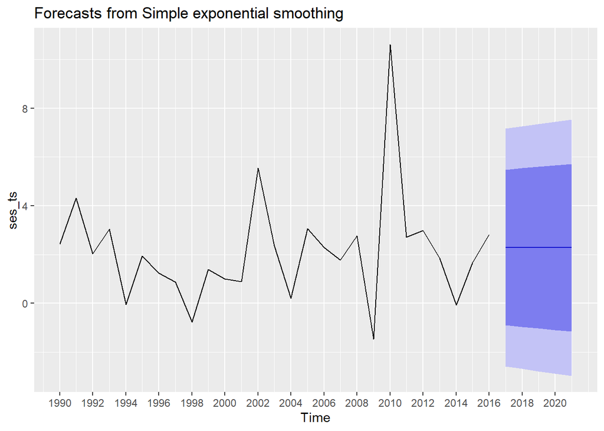

```r
autoplot(ses(ses_ts,h=5,alpha=0.2)) +
  scale_x_continuous(breaks=seq(1990,2021,2))
```

## **Holt’s method**

### The data exhibits clear trend and no seasonal pattern, therefore Holt’s method is suitable in this example.

### Formulas:

#### *alpha and beta = smoothing parameters

#### *h = number of prediction steps ahead

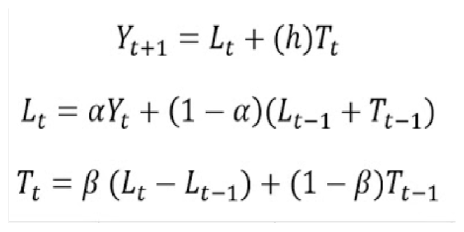

```r
ggplot() +
    background_image(readPNG("images/holts.png"))
```

```r
holt_ts <- expsmooth::usgdp
```

### The data ranges from Q1 1947 to Q1 2006. Given that it’s financial data, values from half century ago most likely have 0 influence on values from 2000 + years. In fact, when holt’s model was applied to the whole data set (meaning 1947-2006), the alpha value was equal to 0.9999, which indicates very strong influence of the most actual values and almost 0 influence of the oldest values. To avoid such high values of alpha and making the model more applicable, it was decided to take data points only from 1990-2006.

```r
time(holt_ts)
```

```
##         Qtr1    Qtr2    Qtr3    Qtr4
## 1947 1947.00 1947.25 1947.50 1947.75
## 1948 1948.00 1948.25 1948.50 1948.75
## 1949 1949.00 1949.25 1949.50 1949.75
## 1950 1950.00 1950.25 1950.50 1950.75
## 1951 1951.00 1951.25 1951.50 1951.75
## 1952 1952.00 1952.25 1952.50 1952.75
## 1953 1953.00 1953.25 1953.50 1953.75
## 1954 1954.00 1954.25 1954.50 1954.75
## 1955 1955.00 1955.25 1955.50 1955.75
## 1956 1956.00 1956.25 1956.50 1956.75
## 1957 1957.00 1957.25 1957.50 1957.75
## 1958 1958.00 1958.25 1958.50 1958.75
## 1959 1959.00 1959.25 1959.50 1959.75
## 1960 1960.00 1960.25 1960.50 1960.75
```

[output cut: 46 more lines]

```r
holt_ts <- window(holt_ts,start = 1990, end = 2006, frequency = 4)
```

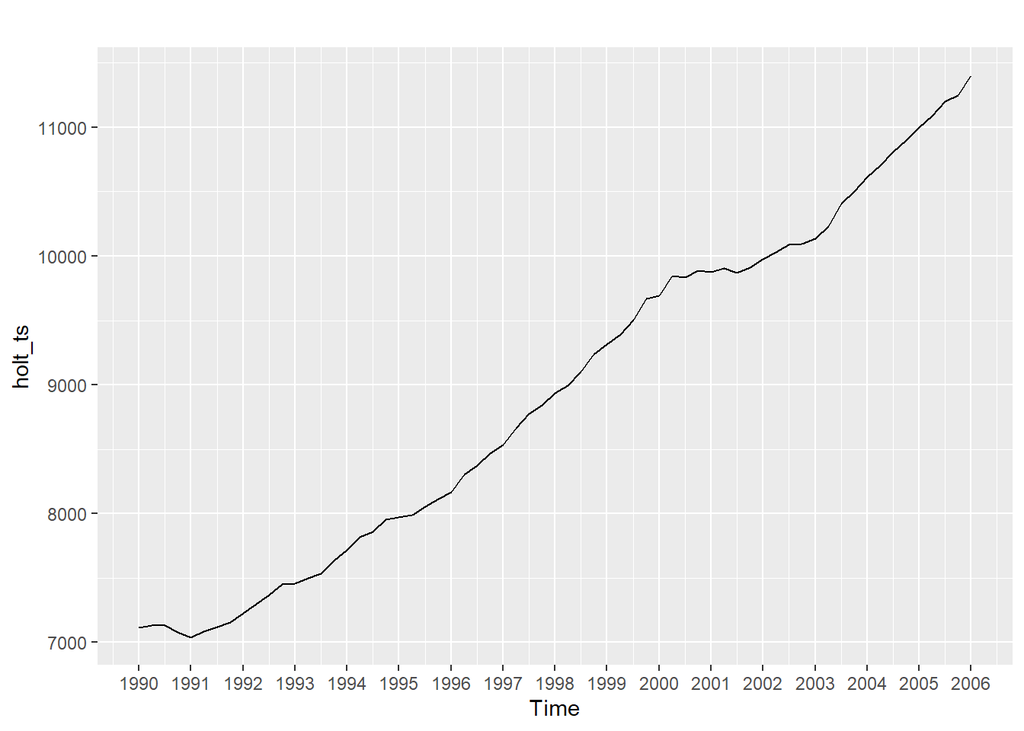

```r
autoplot(holt_ts)+
  scale_x_continuous(breaks=seq(1990,2006,1))
```

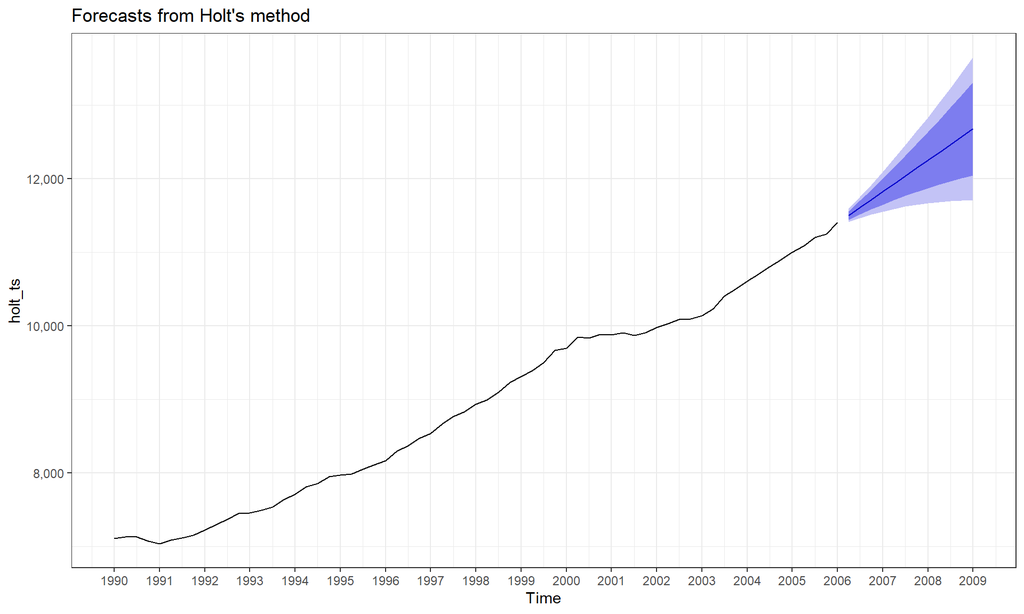

```r
autoplot(holt(holt_ts,h=12,damped = FALSE)) +
  scale_y_continuous(labels = comma_format())+
  scale_x_continuous(breaks=seq(1990,2010,1))+
  theme_bw()
```

```r
holt_model <- holt(holt_ts,h=12,damped = FALSE)
```

```r
holt_model
```

```
##         Point Forecast    Lo 80    Hi 80    Lo 95    Hi 95
## 2006 Q2       11504.46 11446.64 11562.29 11416.03 11592.90
## 2006 Q3       11611.31 11517.61 11705.02 11468.00 11754.62
## 2006 Q4       11718.16 11584.94 11851.38 11514.41 11921.90
## 2007 Q1       11825.00 11648.58 12001.42 11555.19 12094.81
## 2007 Q2       11931.85 11708.72 12154.98 11590.60 12273.09
## 2007 Q3       12038.69 11765.54 12311.85 11620.94 12456.45
## 2007 Q4       12145.54 11819.22 12471.86 11646.47 12644.61
## 2008 Q1       12252.39 11869.92 12634.85 11667.46 12837.32
## 2008 Q2       12359.23 11917.79 12800.68 11684.10 13034.37
## 2008 Q3       12466.08 11962.94 12969.22 11696.59 13235.56
## 2008 Q4       12572.92 12005.49 13140.36 11705.11 13440.74
## 2009 Q1       12679.77 12045.54 13314.00 11709.80 13649.74
```

```r
holt_model[['model']]
```

```
## Holt's method
##
## Call:
##  holt(y = holt_ts, h = 12, damped = FALSE)
##
##   Smoothing parameters:
##     alpha = 0.9128
##     beta  = 0.3625
##
##   Initial states:
##     l = 7114.0924
##     b = 0.6371
##
##   sigma:  45.1184
##
##      AIC     AICc      BIC
## 772.4144 773.4313 783.2863
```

## **Holt-Winters’ method**

### Holt-Winters’ model is applicable if there is both trend and seasonality in the time series.

### Formulas for additive and multiplicative models:

#### *alpha is a smoothing parameter for the level component

#### *beta is a smoothing paramater for the trend component (the equation is the same as in the Holt’s model)

#### *gamma is a smoothing paramater for the seasonal component

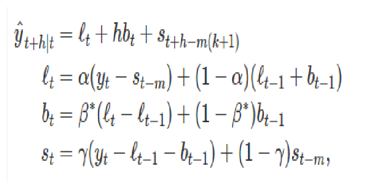

```r
ggplot() +
    background_image(readPNG("images/holtwinters_formula.png"))
```

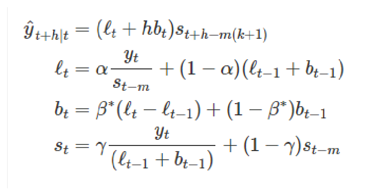

```r
ggplot() +
    background_image(readPNG("images/holtwinters_multiplicative.png"))
```

```r
holt_winter <- fpp2::a10
```

```r
time(holt_winter)
```

```
##           Jan      Feb      Mar      Apr      May      Jun      Jul      Aug
## 1991                                                       1991.500 1991.583
## 1992 1992.000 1992.083 1992.167 1992.250 1992.333 1992.417 1992.500 1992.583
## 1993 1993.000 1993.083 1993.167 1993.250 1993.333 1993.417 1993.500 1993.583
## 1994 1994.000 1994.083 1994.167 1994.250 1994.333 1994.417 1994.500 1994.583
## 1995 1995.000 1995.083 1995.167 1995.250 1995.333 1995.417 1995.500 1995.583
## 1996 1996.000 1996.083 1996.167 1996.250 1996.333 1996.417 1996.500 1996.583
## 1997 1997.000 1997.083 1997.167 1997.250 1997.333 1997.417 1997.500 1997.583
## 1998 1998.000 1998.083 1998.167 1998.250 1998.333 1998.417 1998.500 1998.583
## 1999 1999.000 1999.083 1999.167 1999.250 1999.333 1999.417 1999.500 1999.583
## 2000 2000.000 2000.083 2000.167 2000.250 2000.333 2000.417 2000.500 2000.583
## 2001 2001.000 2001.083 2001.167 2001.250 2001.333 2001.417 2001.500 2001.583
## 2002 2002.000 2002.083 2002.167 2002.250 2002.333 2002.417 2002.500 2002.583
## 2003 2003.000 2003.083 2003.167 2003.250 2003.333 2003.417 2003.500 2003.583
## 2004 2004.000 2004.083 2004.167 2004.250 2004.333 2004.417 2004.500 2004.583
```

[output cut: 23 more lines]

```r
holt_winter <- window(holt_winter,start=2000,end=c(2008,6),frequency=12)
```

```r
holt_winter
```

```
##            Jan       Feb       Mar       Apr       May       Jun       Jul
## 2000 12.511462  7.457199  8.591191  8.474000  9.386803  9.560399 10.834295
## 2001 14.497581  8.049275 10.312891  9.753358 10.850382  9.961719 11.443601
## 2002 16.300269  9.053485 10.002449 10.788750 12.106705 10.954101 12.844566
## 2003 16.828350  9.800215 10.816994 10.654223 12.512323 12.161210 12.998046
## 2004 18.003768 11.938030 12.997900 12.882645 13.943447 13.989472 15.339097
## 2005 20.778723 12.154552 13.402392 14.459239 14.795102 15.705248 15.829550
## 2006 23.486694 12.536987 15.467018 14.233539 17.783058 16.291602 16.980282
## 2007 28.038383 16.763869 19.792754 16.427305 21.000742 20.681002 21.834890
## 2008 29.665356 21.654285 18.264945 23.107677 22.912510 19.431740
##            Aug       Sep       Oct       Nov       Dec
## 2000 10.643751  9.908162 11.710041 11.340151 12.079132
## 2001 11.659239 10.647060 12.652134 13.674466 12.965735
## 2002 12.196500 12.854748 13.542004 13.287640 15.134918
## 2003 12.517276 13.268658 14.733622 13.669382 16.503966
## 2004 15.370764 16.142005 16.685754 17.636728 18.869325
## 2005 17.554701 18.100864 17.496668 19.347265 20.031291
## 2006 18.612189 16.623343 21.430241 23.575517 23.334206
## 2007 23.930204 22.930357 23.263340 25.250030 25.806090
## 2008
```

### Data exhibits both trend and multiplicative seasonality

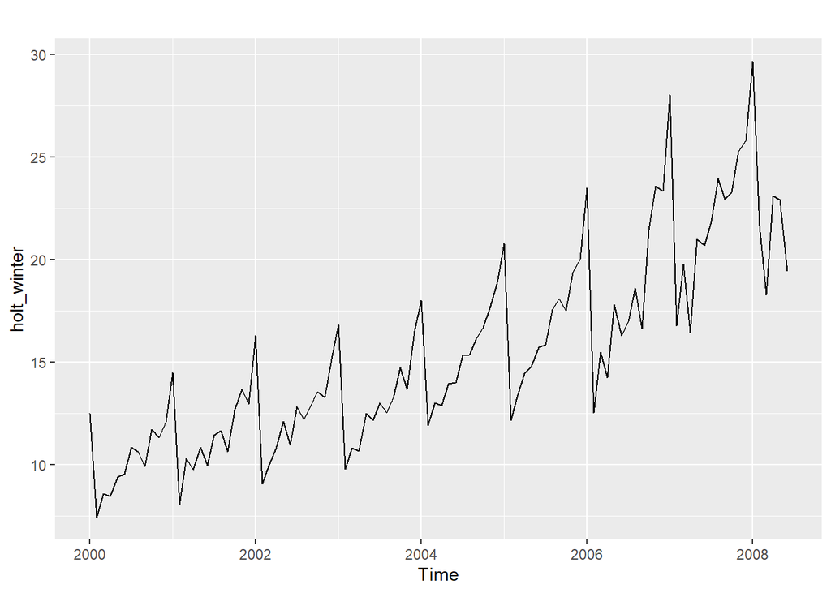

```r
autoplot(holt_winter)
```

```r
holt_winter_mod <- hw(holt_winter,seasonal = "multiplicative",h = 12)
```

```r
holt_winter_mod
```

```
##          Point Forecast    Lo 80    Hi 80    Lo 95    Hi 95
## Jul 2008       23.29383 21.35205 25.23560 20.32414 26.26352
## Aug 2008       24.09195 22.03455 26.14936 20.94542 27.23848
## Sep 2008       24.10570 21.99967 26.21173 20.88480 27.32660
## Oct 2008       26.25496 23.91116 28.59876 22.67043 29.83949
## Nov 2008       27.19620 24.71821 29.67418 23.40644 30.98595
## Dec 2008       28.41725 25.77717 31.05732 24.37960 32.45489
## Jan 2009       32.94393 29.82610 36.06176 28.17562 37.71224
## Feb 2009       19.99713 18.07084 21.92342 17.05112 22.94313
## Mar 2009       21.77418 19.64096 23.90740 18.51170 25.03666
## Apr 2009       21.86796 19.69059 24.04532 18.53796 25.19795
## May 2009       24.34549 21.88352 26.80747 20.58022 28.11076
## Jun 2009       23.06648 20.69881 25.43416 19.44544 26.68753
```

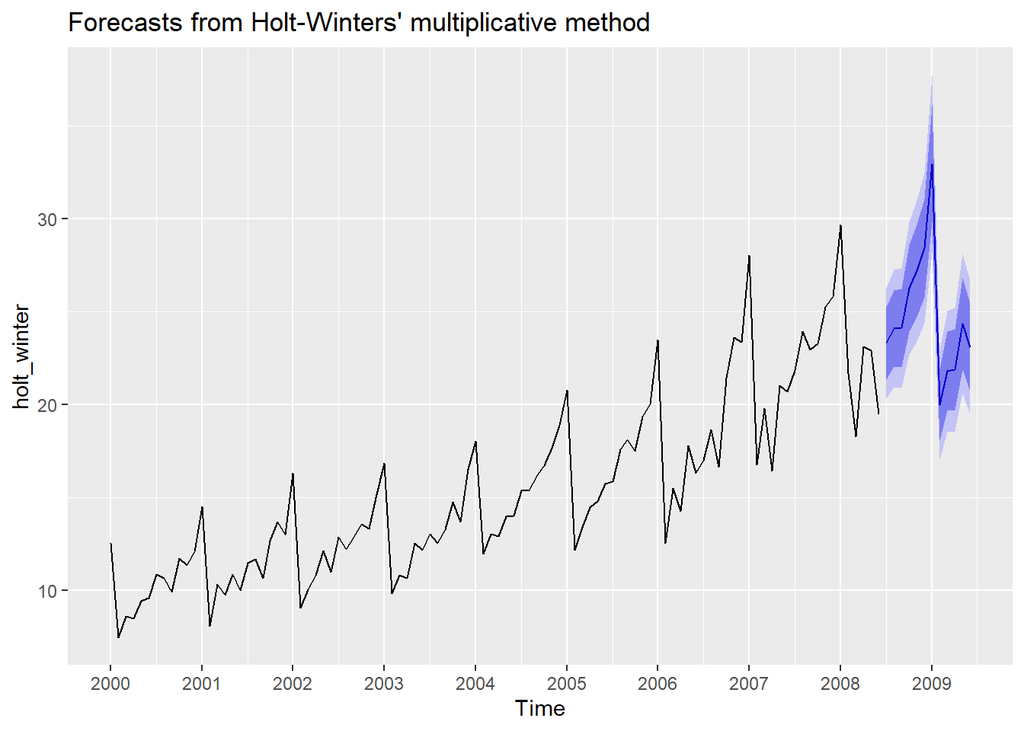

```r
autoplot(holt_winter_mod) +
  scale_x_continuous(breaks = seq(2000,2009,by=1))
```

```r
holt_winter_mod[['model']]
```

```
## Holt-Winters' multiplicative method
##
## Call:
##  hw(y = holt_winter, h = 12, seasonal = "multiplicative")
##
##   Smoothing parameters:
##     alpha = 0.2233
##     beta  = 1e-04
##     gamma = 0.0024
##
##   Initial states:
##     l = 8.7836
##     b = 0.1498
##     s = 1.1491 1.1066 1.0749 0.9932 0.9984 0.971
##            0.8999 0.9555 0.8634 0.8647 0.7992 1.3241
##
##   sigma:  0.065
##
##      AIC     AICc      BIC
## 479.8456 487.1313 524.4701
```

### References:

1. https://www.geeksforgeeks.org/exponential-smoothing-in-r-programming/
2. https://otexts.com/fpp2/holt-winters.html
3. https://otexts.com/fpp2/holt.html